# White Wine Quality Analysis by Min Lai

### Plot Two

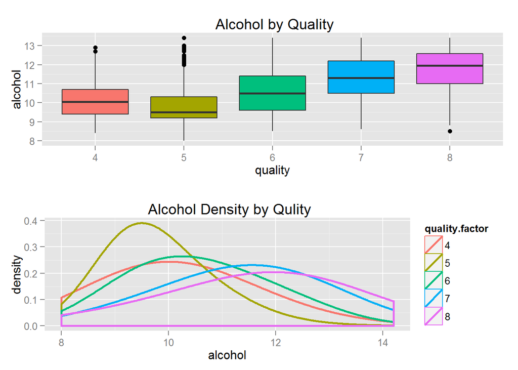

### Plot Three

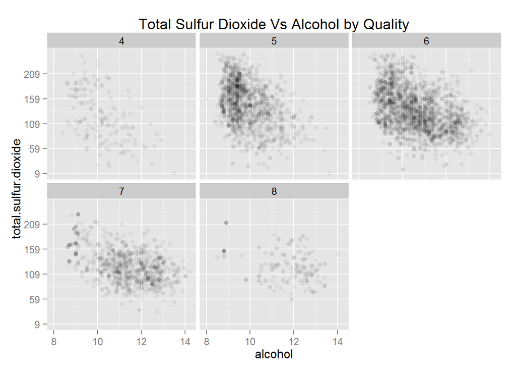

### Description Three

Since alcohol has very strong correlation with quality. I would like investigate correlation between alcohol and other features. If alcohol has very strong correlation with other feature, that feature may not be a good candidate as independent feature to build regression model. To fix the over plotting problem in Multivariate section, I faceted the scatter plot by quality. The pattern displays better in facet wrapped plot. As alcohol increases, total sulfur dioxide decrease, especially for wines with quality 4, 5, 6. So it looks like total sulfur dioxide may not be a good choice as independent feature in quality modeling.

# Reflection

I picked up this dataset because I started to like drinking wines two years ago. I really curious if I can find some clue to tell good wines from bad ones from their chemical attributes. This set has 4898 white wine samples which is a good size for practice purpose not too big but large enough to draw nice plots.

I started with each individual variables. Wine quality are normal distributed which makes sense since most wines are in the median quality which probably sell at affordable price. So demands for this type of wine is the largest. Normal distributions are also can be seen in following features: fixed acidity, volatile acidity, citric acidity, free sulfur dioxide, total sulfur dioxide, density, pH. So I initially thought there should be a strong linear relationship between quality and other features like alcohol, pH, residual sugar, acidity by my intuition.

Then I paired other features with quality to explore relationship. To my surprise, I only see strong correlation between quality and alcohol. There are visible but not so strong correlation between quality and fixed acidity, quality and total sulfur dioxide. pH, residual sugar were my top candidates but to my disappointment, I couldn’t find any visible correlation there. I also found the alcohol and residual sugar and density has negative correlations. And residual sugar and density has strong correlation. It looks like that some features are related to each other. What features should be included to build regression model for quality is still a question.

Finally, I added third feature to the pairs to search for features besides alcohol for regression model. I did find that total sulfur dioxide and fixed acidity enhances the correlation between alcohol and quality. So I tried build a linear model using alcohol, total sulfur dioxide, fixed acidity, pH and residual sugar. It looks like that model is not very successful since the R square is very low only 0.19. That did bother me lot. However, through the analysis in this project gave me lots of insight of about replationships between features in this dataset, which lays a fundation to find a feasible regression model between white wine quality and its chemical properties.

Here are some of my thought about the this dataset and possible improvement beyond scope of this project:

1. Wines samples in this dataset are all from particular area in Portugal which may have some bias related to that region.
2. Best and worst quality sample size are very small, which makes the modeling in high end and low end part is not very accurate.
3. pH, and residual sugar should play a role in wine’s taste, however, I failed to find correlation in this dataset, which tells me that there may be something missing in this dataset. Or this feature can be transformed in a way that some relationship can be better represented.
4. Alcohol has strong correction with some features like density, total sulfur dioxide, pH, so may be a new composite feature can be created for alcohol, density, dioxide, pH which can used for building a better model.
5. The quality is scaled from 0-10. In this dataset, it ranges from 3 to 9. It looks like a categorical feature to me. So linear model may not be the best way to predict. Other regression model can be used to classify wine quality by its chemical property.